# Introduction

Our purpose is to look at how to use and interpret the Shapley values, plots, and other information produced by the SHAP package.

To learn more about Shapley values, the SHAP package, and how these are used to help us interpret our machine learning models, please refer to these resources:

- [A Unified Approach to Interpreting Model Predictions](https://arxiv.org/abs/1705.07874)

  > Scott Lundberg, Su-In Lee
- [Consistent feature attribution for tree ensembles](https://arxiv.org/abs/1706.06060)

  > Scott M. Lundberg, Su-In Lee
- [Consistent Individualized Feature Attribution for Tree Ensembles](https://arxiv.org/abs/1802.03888)

  > Scott M. Lundberg, Gabriel G. Erion, Su-In Lee
- [A game theoretic approach to explain the output of any machine learning model.](https://github.com/slundberg/shap) >
- [Interpretable Machine Learning: A Guide for Making Black Box Models Explainable. 5.9 Shapley Values](https://christophm.github.io/interpretable-ml-book/shapley.html)

  > Christoph Molnar, 2019-12-17
- [Interpretable Machine Learning: A Guide for Making Black Box Models Explainable. 5.10 SHAP (SHapley Additive exPlanations](https://christophm.github.io/interpretable-ml-book/shap.html)

  > Christoph Molnar, 2019-12-17
- [Interpretable Machine Learning with XGBoost](https://towardsdatascience.com/interpretable-machine-learning-with-xgboost-9ec80d148d27?gi=187ef710fdda)

  > Scott Lundberg, Apr 17, 2018
- [Explain Your Model with the SHAP Values](https://towardsdatascience.com/explain-your-model-with-the-shap-values-bc36aac4de3d)

  > Dataman, Sep 14, 2019

# Create a model to interpret

First, we'll load some packages.

```python
import pandas as pd
import xgboost
import shap
from sklearn import datasets as ds
```

Next, we'll load some data. Let's use the California housing data set.

```python
calif_house_data = ds.fetch_california_housing()

print('\n')
print(calif_house_data['data'])
print('\n')
print(calif_house_data['target'])
print('\n')
print(calif_house_data['feature_names'])
print('\n')
print(calif_house_data['DESCR'])
print('\n')
print('Features - # rows, # columns:', calif_house_data['data'].shape)
print('\n')
print('Target variable - # rows:', calif_house_data['target'].shape)
```

```
[[   8.3252       41.            6.98412698 ...    2.55555556
    37.88       -122.23      ]
 [   8.3014       21.            6.23813708 ...    2.10984183
    37.86       -122.22      ]
 [   7.2574       52.            8.28813559 ...    2.80225989
    37.85       -122.24      ]
 ...
 [   1.7          17.            5.20554273 ...    2.3256351
    39.43       -121.22      ]
 [   1.8672       18.            5.32951289 ...    2.12320917
    39.43       -121.32      ]
 [   2.3886       16.            5.25471698 ...    2.61698113
    39.37       -121.24      ]]


[4.526 3.585 3.521 ... 0.923 0.847 0.894]


['MedInc', 'HouseAge', 'AveRooms', 'AveBedrms', 'Population', 'AveOccup', 'Latitude', 'Longitude']


.. _california_housing_dataset:

California Housing dataset
--------------------------

**Data Set Characteristics:**

    :Number of Instances: 20640

    :Number of Attributes: 8 numeric, predictive attributes and the target

    :Attribute Information:
        - MedInc        median income in block
        - HouseAge      median house age in block
        - AveRooms      average number of rooms
        - AveBedrms     average number of bedrooms
        - Population    block population
        - AveOccup      average house occupancy
        - Latitude      house block latitude
```

[output cut: 13 more lines]

```

It can be downloaded/loaded using the
:func:`sklearn.datasets.fetch_california_housing` function.

.. topic:: References

    - Pace, R. Kelley and Ronald Barry, Sparse Spatial Autoregressions,
      Statistics and Probability Letters, 33 (1997) 291-297



Features - # rows, # columns: (20640, 8)


Target variable - # rows: (20640,)
```

The data set has 20640 observations, 8 features, and 1 target variable. Let's put all of that into a data frame.

```python
cah_df = pd.DataFrame(calif_house_data['data'])
cah_df.columns = calif_house_data['feature_names']
cah_df['price'] = calif_house_data['target']

pd.set_option('display.max_columns', 12)
cah_df.head()
```

|  | MedInc | HouseAge | AveRooms | AveBedrms | Population | AveOccup | Latitude | Longitude | price |
| --- | --- | --- | --- | --- | --- | --- | --- | --- | --- |
| 0 | 8.3 | 41.0 | 7.0 | 1.0 | 322.0 | 2.6 | 37.9 | -122.2 | 4.5 |
| 1 | 8.3 | 21.0 | 6.2 | 1.0 | 2401.0 | 2.1 | 37.9 | -122.2 | 3.6 |
| 2 | 7.3 | 52.0 | 8.3 | 1.1 | 496.0 | 2.8 | 37.9 | -122.2 | 3.5 |
| 3 | 5.6 | 52.0 | 5.8 | 1.1 | 558.0 | 2.5 | 37.9 | -122.2 | 3.4 |
| 4 | 3.8 | 52.0 | 6.3 | 1.1 | 565.0 | 2.2 | 37.9 | -122.2 | 3.4 |

The target variable *price* is continuous, so we can model it as a regression problem. It and the feature *MedInc* (median income) have apparently been log-transformed. We'll use them as they are, rather than transforming them.

Now we can train a model that we can interpret with Shapley values.

Because we're interested only in how to use Shapley values, we're not going to concern ourselves with proper data science practices, like splitting our data into training and testing sets or even concerning ourselves much with how well our model performs.

```python
x = cah_df.iloc[:, :8]
y = cah_df['price']
model = xgboost.train({'learning_rate': 0.01}, xgboost.DMatrix(x, label=y), 100)
cah_df['predictions'] = model.predict(xgboost.DMatrix(x))
```

```
Series.base is deprecated and will be removed in a future version
Series.base is deprecated and will be removed in a future version
```

Let's take a peek at how our predictions compare to the actual house prices.

```python
cah_df[['price', 'predictions']].head()
```

|  | price | predictions |
| --- | --- | --- |
| 0 | 4.5 | 3.1 |
| 1 | 3.6 | 2.9 |
| 2 | 3.5 | 2.6 |
| 3 | 3.4 | 2.4 |
| 4 | 3.4 | 1.8 |

We can look at the prediction error as a proportion of the target variable.

```python
proportional_error = (cah_df['price'] - cah_df['predictions']).abs() / cah_df['price']
print('\n')
print(proportional_error.mean())
print(proportional_error.median())
```

```
0.2758806381767824
0.2659469118900447
```

If we were deeply concerned with how our model is performing, we might transform our target variable into actual dollar amounts (which would be easier to interpret), summarize our prediction error in dollar terms, plot our errors and analyze for which kinds of houses our model is performing well and poorly, and do other error analyses. However, while the model is probably overfitting and could be easily improved, we're just going to pretend that it's performing well enough and move along to using Shapley values to interpret it.

# Explaining predictions for an individual observation

Let's create some SHAP values to explain our model's predictions.

```python
shap.initjs()
explainer = shap.TreeExplainer(model)
shap_values = explainer.shap_values(x)
```

```
Setting feature_perturbation = "tree_path_dependent" because no background data was given.
```

Notice that the shap values matrix is the same size as our *x* matrix that contains all the feature values for each observation (i.e., each row of the matrix).

```python
print('\n')
print('Features matrix - # rows, # columns:', x.shape)
print('\n')
print('SHAP values matrix - # rows, # columns:', shap_values.shape)
```

```
Features matrix - # rows, # columns: (20640, 8)


SHAP values matrix - # rows, # columns: (20640, 8)
```

That means that there is one SHAP value for each value in our feature matrix. In other words, each observation (row) has a SHAP value for each of its features (columns) that explains that feature's contribution to the model's prediction for that observation.

We can peek at the SHAP values just to see what they look like.

```python
shap_values
```

```
array([[ 1.5014205 ,  0.12187751, -0.01567233, ...,  0.00558747,
        -0.03615549,  0.0548582 ],
       [ 1.241629  , -0.04290823, -0.01426417, ...,  0.15332335,
        -0.01513546,  0.06667963],
       [ 1.0727512 ,  0.13276996, -0.0110674 , ..., -0.0291234 ,
        -0.10895026,  0.0459473 ],
       ...,
       [-0.5170386 , -0.02573242, -0.03896352, ...,  0.0507761 ,
        -0.25843522,  0.03407124],
       [-0.54416865, -0.0239558 , -0.04050735, ...,  0.15101643,
        -0.308521  ,  0.02929365],
       [-0.40648058, -0.02621501, -0.04948353, ..., -0.01164584,
        -0.22971545,  0.02734175]], dtype=float32)
```

The SHAP package provides some visualizations to help us understand how much each feature contributes to each prediction. Let's look at a prediction for a single observation (row) in our data set. The SHAP values explain why a prediction for a single observation is different from the average prediction for all the observations in the data set. Here's our model's average prediction for our data set:

```python
explainer.expected_value
```

```
1.4923179
```

### Decision plot

Here is the SHAP package's *decision plot* for explaining why a single observation deviates from the average prediction:

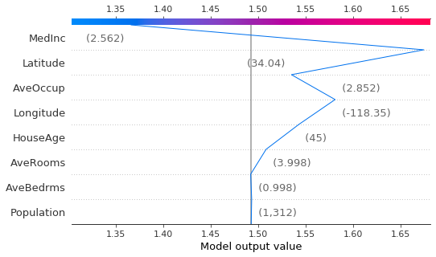

```python
row = 4771
shap.decision_plot(explainer.expected_value, shap_values[row, :], x.iloc[row, :])
```

As we move from the bottom to the top of the plot, we notice that *Population* and *AveBedrms* (average number of bedrooms) change the prediction very little. Then *AveRooms* (average number of rooms), *HouseAge* (median house age), and *Longitude* all increase the median price of the houses in this census block.

The values in parentheses in each row show the value for each feature for the houses in this census block. So, we can see that houses in this block have an average of 4 rooms and are 45 years old on average. Compared to all the houses in the data set, these values of 4 rooms and 45 years old increase the median price of the houses.

As we move further up the plot, we notice that the census block's latitude increases the median price, but the average occupancy (*AveOccup*) and median income (*MedInc*) decrease the predicted median price, according to our model.

When we sum up all the SHAP-calculated effects of the features, we see that the model predicts that the median price for houses in this census block is 1.37, which is below 1.49, the average predicted median price for all houses in all the census blocks in this data set. that value of 1.37 is where the blue squiggly line ends up at the top of the plot.

## Force plot

The SHAP package provides another type of plot, the *force plot*, to visualize the same information as the *decision plot* that we discussed above:

```python
shap.force_plot(explainer.expected_value, shap_values[row, :], x.iloc[row, :])
```

[output not shown]

# Explaining predictions for the entire data set

### Force plot

Now that we understand the *force plot* for a single observation, we can look at a force plot for many observations. Our entire data set has 20640 observations. That's too many to plot, so we'll take a random sample of those observations for our *force plot*.

```python
n = 200
pd.np.random.seed(16719)
row_idx = pd.np.random.randint(0, x.shape[0], n)

x_sample = x.iloc[row_idx, :]
shap_sample = shap_values[row_idx, :]
```

```python
shap.force_plot(explainer.expected_value, shap_sample, x_sample, link='logit')
```

[output not shown]

### Feature importances summary plot

This *force plot* for many observations is terrific for looking at the model's predictions with granularity. But what if we want a simpler summary of how important each feature is in making predictions for the entire data set -- something like *feature importance*?

The SHAP package provides this as a *summary plot*. Here it is for our data:

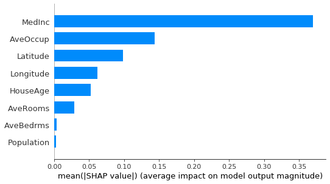

```python
shap.summary_plot(shap_values, x, plot_type='bar')
```

These summaries, or feature importances, are calculated simply by taking the absolute values of all the Shapley values and averaging them for each feature. Look closely, and you can see that the calculation below matches the plot *summary plot* above.

```python
pd.Series(pd.np.abs(shap_values).mean(axis=0),
          index=cah_df.columns[:x.shape[1]]).sort_values(ascending=False)
```

```
MedInc        3.7e-01
AveOccup      1.4e-01
Latitude      9.9e-02
Longitude     6.2e-02
HouseAge      5.2e-02
AveRooms      2.9e-02
AveBedrms     3.8e-03
Population    2.3e-03
dtype: float32
```

Just to make sure we understand what's happening here, let's look at the Shapley values again:

```python
print(shap_values)
```

```
[[ 1.5014205   0.12187751 -0.01567233 ...  0.00558747 -0.03615549
   0.0548582 ]
 [ 1.241629   -0.04290823 -0.01426417 ...  0.15332335 -0.01513546
   0.06667963]
 [ 1.0727512   0.13276996 -0.0110674  ... -0.0291234  -0.10895026
   0.0459473 ]
 ...
 [-0.5170386  -0.02573242 -0.03896352 ...  0.0507761  -0.25843522
   0.03407124]
 [-0.54416865 -0.0239558  -0.04050735 ...  0.15101643 -0.308521
   0.02929365]
 [-0.40648058 -0.02621501 -0.04948353 ... -0.01164584 -0.22971545
   0.02734175]]
```

```python
print('SHAP values matrix - # rows, # columns:', shap_values.shape)
```

```
SHAP values matrix - # rows, # columns: (20640, 8)
```

Remember, each row is an observation, which represents a census block of houses, and we have 20640 census blocks. Each column is a feature, and there are 8 features.

All we did in the calculation above was to average all the (absolute values of the) 20640 Shapley values in each column. That gave us 8 sums, one for each feature, and those are our 8 feature importances for this model. It's that simple.

Let's pause and consider this for a moment, because this is a really important point: the feature importances for the entire model are calculated directly from their importances for individual observations. In other words, the importances are consistent between the model's global behavior and its local behavior. This consistency is a remarkable and really important characteristic that many model interpretability methods do not offer.

The SHAP package also provides a more granular look at feature importances for the entire data set.

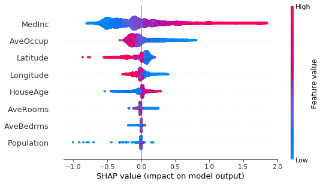

```python
shap.summary_plot(shap_values, x)
```

Here the Shapley values every observation are plotted for each feature. Additionally, the coloring indicates whether low (or high) values of each feature increase (or decrease) the model's predictions.

For example, we can see that high median incomes (*MedInc*) increase the predictions of house prices (i.e., the Shapley values are greater than zero) while low median incomes decrease those predictions (i.e., the Shapley values are < 0). Also, the effects of *MedInc* on the model's predictions exhibit a positively skewed distribution: most values of *MedInc* decrease the model's predictions, while a long tail of high *MedInc* values increase the model's predictions.

With *AveOccup*, there is a similar effect in the opposite direction. There is a positively skewed distribution so that low values of average occupancy increase the model's predictions. (Note that the univariate distribution of *AveOccup* is negatively skewed, while its effect on the model's predictions are positively skewed.)

# Explaining predictions for a data set subgroup

### Feature importances summary plot

Remember, to calculate the model's global feature importances based on the Shapley values, we averaged the (absolute values of the) Shapley values for each feature. That gave us this plot:

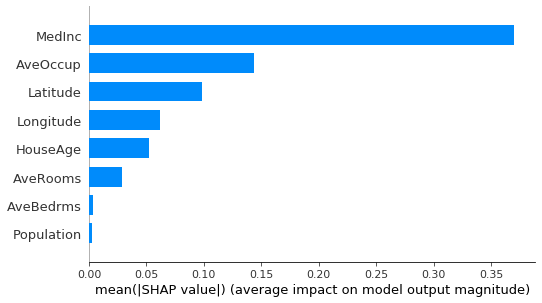

```python
 pd.Series(pd.np.abs(shap_values).mean(axis=0),
           index=cah_df.columns[:x.shape[1]]).sort_values(ascending=False)

 shap.summary_plot(shap_values, x, plot_type='bar')
```

This additivity, or linearity, property of Shapley values allows us to aggregate our explanations across individual observations to explain predictions for groups. In the plot above, we looked at the entire data set, but we can also look at feature importances for subgroups within the data set.

As an example, let's look only at census blocks where houses on average have at least 6 rooms.

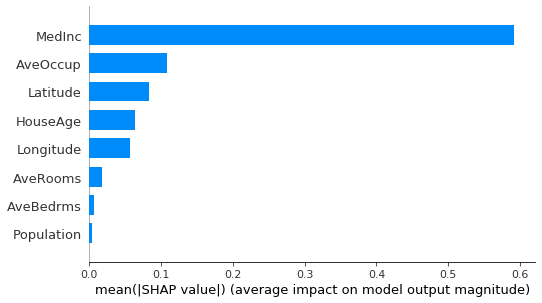

```python
mask = x['AveRooms'] >= 6
shap.summary_plot(shap_values[mask, :], x.loc[mask, :], plot_type='bar')
```

We can see that for this subgroup, *MedInc* is even more important for generating the model's predictions, compared to *MedInc*'s importance for the entire data set.

# Feature interactions

### Example 1: MedInc & AveOccup

The SHAP package lets us explore how our features interact with each other to produce our model's predictions. Let's look at an example.

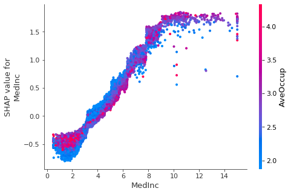

```python
shap.dependence_plot(
    ind=cah_df.columns[0], shap_values=shap_values, features=x,
    interaction_index=5)
```

We're looking at how median income for the census block (*MedInc*) affects the model's predictions. Ignore the color and *AveOccup* for now. The median income is plotted on the x-axis while its SHAP-measured influence on the model's predictions is plotted on the y-axis. Overall, as median income increases, it tends to increase the model's predictions of house prices.

But notice that that's not the whole story. If we look at a single value for *MedInc*, say where it is equal to 2, notice that the SHAP values have some vertical spread. They range from about -0.8 to -0.3. If *MedInc* were the only predictor influencing its affect on the model's predictions, then all the SHAP values where *MedInc* = 2 should be the same. But they're not; that vertical spread tells us that *MedInc* must be interacting with other features to produce the model's predictions where *MedInc* = 2.

With which features is *MedInc* interacting? Average occupancy (*AveOccup*) is an important one. Notice that where *MedInc* = 2, *AveOccup* positively correlates with *MedInc*'s influence on predictions of house prices. In other words, when average occupancy is low, *MedInc* tends to predict especially low house prices; when average occupancy is high, *MedInc* predicts house prices that are not as low. On the plot where *MedInc* = 2, the red dots are higher on the y-axis than the blue dots. (All the SHAP values where *MedInc* = 2 are negative, so *MedInc* is always decreasing the house price predictions here.)

Now look where *MedInc* = 5. Now the red dots are lower on the y-axis than the blue dots. Now *AveOccup* negatively correlates with *MedInc*'s predictions on house prices.

### Example 2: Latitude & MedInc

We can briefly look at another example. This one looks at how *Latitude* interacts with median income (*MedInc*):

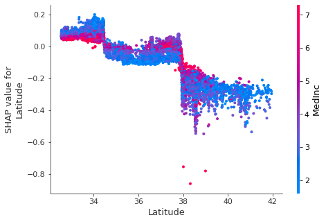

```python
shap.dependence_plot(
    ind=cah_df.columns[6], shap_values=shap_values, features=x,
    interaction_index=0)
```

But there is vertical dispersion, especially in northern California (at and north of 38 degrees). *Latitude* interacts with *MedInc*: *MedInc* negatively correlates with *Latitude*'s influence on house price predictions in southern California (at and south of 34 degrees), positively correlates with it in middle California (between 34 and 38 degrees), and has a less pronounced positive correlation in northern California. (Remember that the data set is from the 1990 Census, so the model's results may not apply to today's housing markets in California.)

### SHAP interaction value matrix

We can calculate the SHAP interaction values.

```python
shap_ixn_values = explainer.shap_interaction_values(x)
```

```python
print(shap_ixn_values[:2, :3, :3])
print('\n')
print('SHAP interaction values - # blocks, # features, # features:', shap_ixn_values.shape)
```

```
[[[ 1.4260510e+00  8.2257584e-02  1.9920701e-02]
  [ 8.2257748e-02  6.5020867e-02  4.8962934e-04]
  [ 1.9920588e-02  4.8963353e-04 -3.1480454e-02]]

 [[ 1.4077024e+00 -2.3955334e-02  1.7470015e-02]
  [-2.3956358e-02 -2.6462477e-02 -3.2996992e-04]
  [ 1.7470062e-02 -3.2996200e-04 -3.0340258e-02]]]


SHAP interaction values - # blocks, # features, # features: (20640, 8, 8)
```

This matrix gives us a SHAP interaction value for every observation (every census block, in this case) and for every combination of features. This way, we can look at how every feature interacts with every other feature for every observation.

We can also look at the overall feature interactions by aggregating across the observations. (Though I'm not certain that this is the correct calculation.)

```python
ixns_by_features = pd.DataFrame(
    pd.np.abs(shap_ixn_values).sum(axis=0),
    index=cah_df.columns[:8],
    columns=cah_df.columns[:8])
```

```python
pd.set_option('precision', 1)
ixns_by_features
```

|  | MedInc | HouseAge | AveRooms | AveBedrms | Population | AveOccup | Latitude | Longitude |
| --- | --- | --- | --- | --- | --- | --- | --- | --- |
| MedInc | 7687.8 | 426.7 | 386.1 | 52.5 | 42.7 | 795.4 | 432.9 | 324.5 |
| HouseAge | 426.7 | 1119.9 | 24.3 | 19.7 | 14.4 | 407.5 | 102.7 | 78.4 |
| AveRooms | 386.1 | 24.3 | 590.5 | 3.0 | 5.4 | 86.1 | 81.1 | 50.9 |
| AveBedrms | 52.5 | 19.7 | 3.0 | 79.8 | 1.0 | 23.2 | 2.9 | 2.6 |
| Population | 42.7 | 14.4 | 5.4 | 1.0 | 34.6 | 15.4 | 3.3 | 3.1 |
| AveOccup | 795.4 | 407.5 | 86.1 | 23.2 | 15.4 | 3025.8 | 255.8 | 147.8 |
| Latitude | 432.9 | 102.7 | 81.1 | 2.9 | 3.3 | 255.8 | 1725.5 | 452.4 |
| Longitude | 324.5 | 78.4 | 50.9 | 2.6 | 3.1 | 147.8 | 452.4 | 1320.0 |

In the table, we can see that *MedInc* interacts most strongly with *AveOccup*, because 795.4 is the highest value in *MedInc*'s column (or row), except for *MedInc*'s value with itself (7687.8).

# Supervised clustering

Lundberg et al. (2019) introduced supervised clustering based on SHAP values. This method provides a way of grouping observations in a data set according to how important the features are in producing a model's predictions.

For our model predicting California house prices, we've already seen that the median income of the census block (*MedInc*) is the most important feature for generating the model's predictions. By clustering on the SHAP values of the features -- instead of on the features themselves -- *MedInc* will automatically be weighted more than the other features in calculating the resulting clusters. Likewise, the other features will be weighted less according to their importances.

Let's do some supervised clustering. First, we'll need to load some extra packages and functions.

```python
import scipy as sp
from scipy.spatial.distance import pdist
from scipy.cluster.hierarchy import fcluster
from sklearn.manifold import TSNE
from matplotlib import pyplot as plt
import plotnine as p9
```

To reduce the computational burden, we'll take a sample of our 20640 census blocks.

```python
n = 400
pd.np.random.seed(19624)
row_idx = pd.np.random.randint(0, x.shape[0], n)
```

```python
cah_sample = cah_df.iloc[row_idx, :].copy().reset_index(drop=True)
shap_sample = shap_values[row_idx, :]
```

We're going to use a hierarchical clustering method that is conveniently available. However, it's not really important which clustering method we choose; you can use any of your favorite clustering methods on SHAP values to do supervised clustering.

```python
# returns 1-dimensional order of indices according to hierarchical clustering
# cluster_order_idx = shap.hclust_ordering(shap_sample)

condensed_distance_matrix = pdist(shap_sample)
cluster_linkage_matrix = sp.cluster.hierarchy.complete(condensed_distance_matrix)

# Cophenetic Correlation Coefficient
# sp.cluster.hierarchy.cophenet(cluster_linkage_matrix)
```

For this hierarchical clustering method, let's plot the dendrogram and decide how many clusters we want to examine.

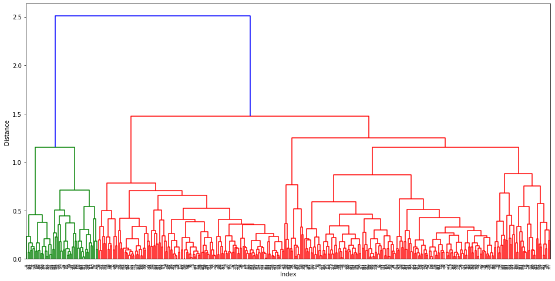

```python
plt.figure(figsize=(16, 8))
plt.ylabel('Distance')
plt.xlabel('Index')
sp.cluster.hierarchy.dendrogram(cluster_linkage_matrix)
plt.show()
```

Let's choose a 3-cluster solution, so our maximum distance is going to be about 1.4. The code below calculates the clusters, uses T-SNE to reduce the dimensionality to 2-dimensions, and then plots those clusters in 2 dimensions.

```python
max_d = 1.4
tsne = TSNE(n_components=2, verbose=1)
tsne_results = tsne.fit_transform(shap_sample)
clusters = fcluster(cluster_linkage_matrix, max_d, criterion='distance')
tsne_colnames = ['t1', 't2']
clusters_colname = 'clusters'
tsne_results_df = pd.DataFrame(tsne_results, columns=tsne_colnames)
tsne_results_df[clusters_colname] = clusters
```

```
[t-SNE] Computing 91 nearest neighbors...
[t-SNE] Indexed 400 samples in 0.000s...
[t-SNE] Computed neighbors for 400 samples in 0.009s...
[t-SNE] Computed conditional probabilities for sample 400 / 400
[t-SNE] Mean sigma: 0.132334
[t-SNE] KL divergence after 250 iterations with early exaggeration: 60.902401
[t-SNE] KL divergence after 1000 iterations: 0.458085
```

```python
plot_title = 'SHAP-Based Clusters in T-SNE SHAP Space'
x_axis_label = 'T-SNE Component 1'
y_axis_label = 'T-SNE Component 2'
xlim = [tsne_results_df.iloc[:, 0].min(), tsne_results_df.iloc[:, 0].max()]
ylim = [tsne_results_df.iloc[:, 1].min(), tsne_results_df.iloc[:, 1].max()]
```

```python
plot = (p9.ggplot(tsne_results_df,
                    p9.aes(y=tsne_results_df.columns[1],
                           x=tsne_results_df.columns[0],
                           group=clusters_colname,
                           color=clusters_colname
                           ))
        + p9.geom_point(size=2)
        + p9.geom_rug()
        + p9.stat_ellipse()
        + p9.xlim(xlim[0], xlim[1])
        + p9.ylim(ylim[0], ylim[1])
        #+ p9.scale_color_gradient(low='blue', high='yellow')
        #+ p9.scale_color_manual(values=colors)
        + p9.theme_light(base_size=18)
        + p9.ggtitle(plot_title)
        + p9.labs(y=y_axis_label,
                  x=x_axis_label)
        )
```

```
Filename: shap_clusters.png
geom_path: Removed 12 rows containing missing values.
```

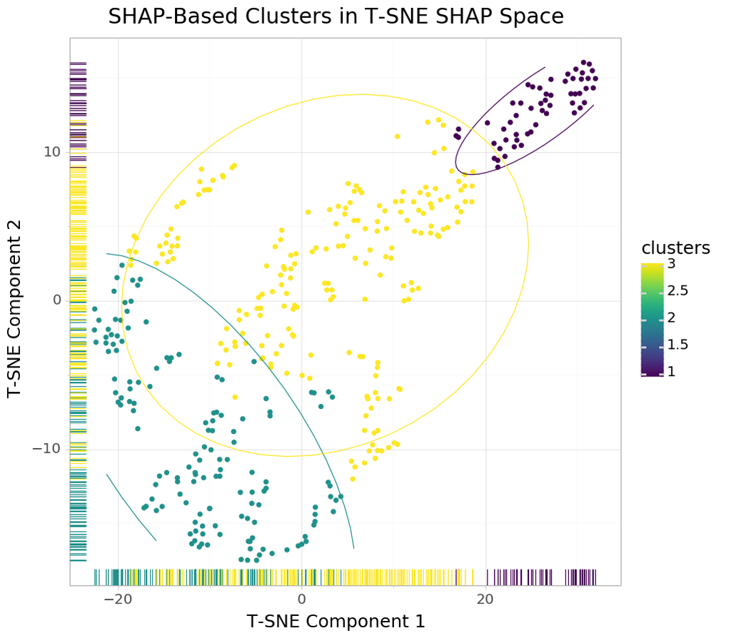

```python
plot_filename = 'shap_clusters.png'
plot.save(plot_filename, width=10, height=10)
from IPython.display import Image
Image(filename=plot_filename)
```

```python
shap_sample_df_colnames = [e + '_shap' for e in cah_df.columns[:shap_sample.shape[1]]]
shap_sample_df = pd.DataFrame(shap_sample, columns=shap_sample_df_colnames)
cah_shap_sample = pd.concat([cah_sample, shap_sample_df], axis=1)
cah_shap_sample[clusters_colname] = clusters
```

```python
pd.set_option('display.max_columns', 20)
cah_shap_sample.groupby(clusters_colname).mean()
```

| clusters | MedInc | HouseAge | AveRooms | AveBedrms | Population | AveOccup | Latitude | Longitude | price | predictions | MedInc_shap | HouseAge_shap | AveRooms_shap | AveBedrms_shap | Population_shap | AveOccup_shap | Latitude_shap | Longitude_shap |
| --- | --- | --- | --- | --- | --- | --- | --- | --- | --- | --- | --- | --- | --- | --- | --- | --- | --- | --- |
| 1 | 7.9 | 27.5 | 7.2 | 1.0 | 1242.2 | 2.8 | 35.3 | -119.5 | 4.0 | 2.7 | 1.2 | 2.0e-02 | -1.5e-02 | -2.8e-03 | 4.3e-03 | -1.2e-02 | 2.3e-02 | 5.3e-03 |
| 2 | 2.4 | 29.7 | 4.7 | 1.1 | 1458.2 | 3.0 | 35.6 | -119.3 | 1.4 | 1.1 | -0.4 | 5.3e-03 | -3.6e-03 | 9.0e-04 | 1.9e-04 | -7.9e-03 | 6.6e-03 | -1.6e-02 |
| 3 | 4.3 | 27.4 | 5.7 | 1.1 | 1504.5 | 2.8 | 35.6 | -119.6 | 2.3 | 1.6 | 0.1 | 7.4e-03 | -1.5e-02 | 6.5e-05 | 6.4e-04 | 1.8e-02 | -2.4e-03 | 4.4e-03 |

The most obvious difference among the clusters is that Cluster #1 has the highest house prices, the highest predicted house prices, and the highest median income (*MedInc*), which is also the most important feature in generating Cluster #1's high predicted house prices, according to the SHAP values for *MedInc* (*MedInc_shap*). In short, Cluster #1 evidently includes the most economically prosperous neighborhoods.

By contrast, Cluster #2 has the lowest house prices, the lowest predicted house prices, and the lowest median income (*MedInc*), which is the most important feature in lowering the model's predictions of Cluster #2's house prices.

Cluster #3 falls between Clusters #1 and #2 on all these statistics. Notice that our T-SNE plot of the clusters capture these relationships, with Cluster #3 data points plotted mostly between data points for Clusters #1 and #2.

If we wanted to examine our data set and our model's predictions in more detail, we might divide our observations into more than 3 clusters and look at boxplots, geography, and other ways of characterizing our clusters. But the primary purpose here is only to briefly demonstrate how supervised clustering can be useful in interpreting a model and understanding the underlying data. Lundberg et al. (2019) provide further details about supervised clustering.

# Conclusion

This concludes our exploration of how to use Shapley values and the SHAP package. The resources cited at the top of this page can provide further information about Shapley values and SHAP. Additionally, Christoph Molnar's book and Tim Miller's paper can provide further insight into the challenges and promise of machine learning interpretability:

- [Interpretable Machine Learning: A Guide for Making Black Box Models Explainable.](https://christophm.github.io/interpretable-ml-book/)

  > Christoph Molnar, 2019-12-17
- [Explanation in Artificial Intelligence: Insights from the Social Sciences](https://arxiv.org/abs/1706.07269)

  > Tim Miller